# Option Pricing

Kathryn Jie

11/19/2020

Put-call Parity

```r
library(NMOF)
```

putCallParity(what, call, put, S, X, tau, r, q = 0, tauD = 0, D = 0)

Example 1: Put-call Parity (continuous div) A non-dividend paying stock has a price of 40 today. A European call option allows buying the stock for 45 for the end of 9 months. The continuosly compounded risk-free rate is 5%. The premium of the call option is 2.84. Determine the premium of a European put option allowing selling the stock for 45 at the end of 9 months.

```r
putCallParity("put", call=2.84, S=40, X=45, tau=9/12, r=0.05, q=0, tauD=0, D=0 )
```

```
## [1] 6.183749
```

```r
putCallParity("call", put=3.91, S=40, X=40, tau=3/12, r=0.04, q=0.02086, tauD=0, D=0)
```

```
## [1] 4.09995
```

Cox, Ross, and Rubinstein Binomial Model

```r
library(fOptions)
```

CRRBinomialTreeOption(TypeFlag = c(“ce”, “pe”, “ca”, “pa”), S, X, Time, r, b, sigma, n, title = NULL, description = NULL) ce: European call pe: European put ca: American call pa: American put

BinomialTreePlot(BinomialTreeValues, dx = -0.025, dy = 0.4, cex = 1, digits = 2, …)

American Call

```r
CRRBinomialTreeOption(TypeFlag = "ca", S = 150, X = 160, Time = 0.5, r = 0.06, b
= 0, sigma = 0.5, n = 2)
```

```
##
## Title:
##  CRR Binomial Tree Option
##
## Call:
##  CRRBinomialTreeOption(TypeFlag = "ca", S = 150, X = 160, Time = 0.5,
##      r = 0.06, b = 0, sigma = 0.5, n = 2)
##
## Parameters:
##           Value:
##  TypeFlag ca
##  S        150
##  X        160
##  Time     0.5
##  r        0.06
##  b        0
##  sigma    0.5
##  n        2
##
## Option Price:
##  16.24143
##
## Description:
##  Thu Nov 19 23:48:55 2020
```

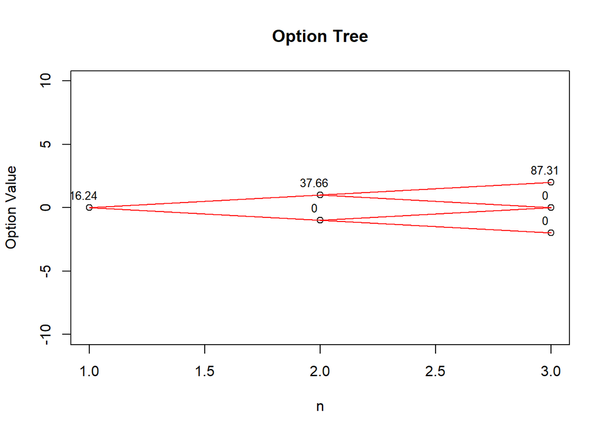

```r
CRRTree = BinomialTreeOption(TypeFlag = "ca", S = 150, X = 160, Time = 0.5, r =
0.06, b = 0, sigma = 0.5, n = 2)
BinomialTreePlot(CRRTree, dy = 1, cex = 0.8, ylim = c(-10, 10),xlab = "n", ylab
= "Option Value")
title(main = "Option Tree")
```

American Put

```r
CRRBinomialTreeOption(TypeFlag = "pa", S=150, X=160, Time=0.5, r=0.06,b=0,sigma=0.5,n=5)
```

```
##
## Title:
##  CRR Binomial Tree Option
##
## Call:
##  CRRBinomialTreeOption(TypeFlag = "pa", S = 150, X = 160, Time = 0.5,
##      r = 0.06, b = 0, sigma = 0.5, n = 5)
##
## Parameters:
##           Value:
##  TypeFlag pa
##  S        150
##  X        160
##  Time     0.5
##  r        0.06
##  b        0
##  sigma    0.5
##  n        5
##
## Option Price:
##  27.19739
##
## Description:
##  Thu Nov 19 23:48:56 2020
```

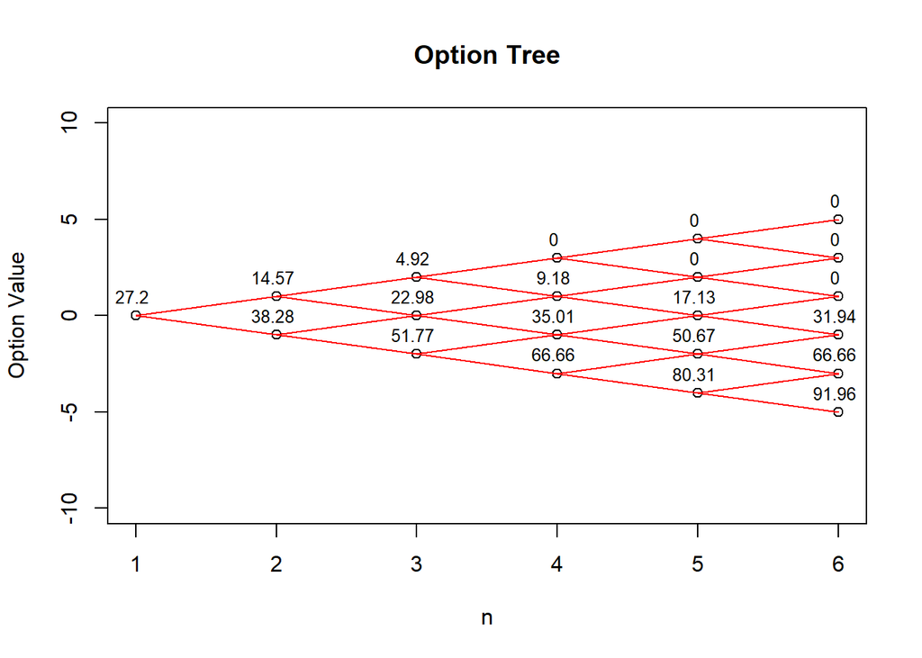

```r
CRRTree = BinomialTreeOption(TypeFlag = "pa", S = 150, X = 160, Time = 0.5, r =
0.06, b = 0, sigma = 0.5, n = 5)
BinomialTreePlot(CRRTree, dy = 1, cex = 0.8, ylim = c(-10, 10),xlab = "n", ylab
= "Option Value")
title(main = "Option Tree")
```

European Call

```r
CRRBinomialTreeOption(TypeFlag = "ce", S = 150, X = 160, Time = 0.5, r = 0.06, b
= 0, sigma = 0.5, n = 2)
```

```
##
## Title:
##  CRR Binomial Tree Option
##
## Call:
##  CRRBinomialTreeOption(TypeFlag = "ce", S = 150, X = 160, Time = 0.5,
##      r = 0.06, b = 0, sigma = 0.5, n = 2)
##
## Parameters:
##           Value:
##  TypeFlag ce
##  S        150
##  X        160
##  Time     0.5
##  r        0.06
##  b        0
##  sigma    0.5
##  n        2
##
## Option Price:
##  16.24143
##
## Description:
##  Thu Nov 19 23:48:56 2020
```

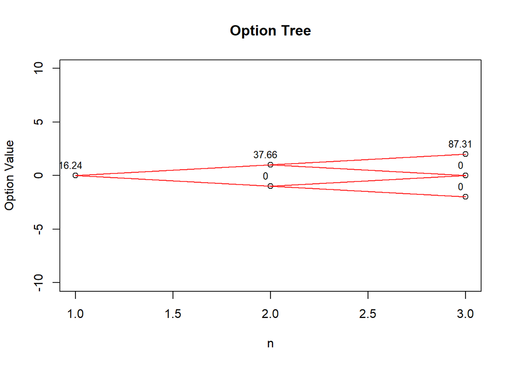

```r
CRRTree = BinomialTreeOption(TypeFlag = "ce", S = 150, X = 160, Time = 0.5, r =
0.06, b = 0, sigma = 0.5, n = 2)
BinomialTreePlot(CRRTree, dy = 1, cex = 0.8, ylim = c(-10, 10),xlab = "n", ylab
= "Option Value")
title(main = "Option Tree")
```

European Put

```r
CRRBinomialTreeOption(TypeFlag = "pe", S = 150, X = 160, Time = 0.5, r = 0.06, b
= 0, sigma = 0.5, n = 5)
```

```
##
## Title:
##  CRR Binomial Tree Option
##
## Call:
##  CRRBinomialTreeOption(TypeFlag = "pe", S = 150, X = 160, Time = 0.5,
##      r = 0.06, b = 0, sigma = 0.5, n = 5)
##
## Parameters:
##           Value:
##  TypeFlag pe
##  S        150
##  X        160
##  Time     0.5
##  r        0.06
##  b        0
##  sigma    0.5
##  n        5
##
## Option Price:
##  27.01062
##
## Description:
##  Thu Nov 19 23:48:56 2020
```

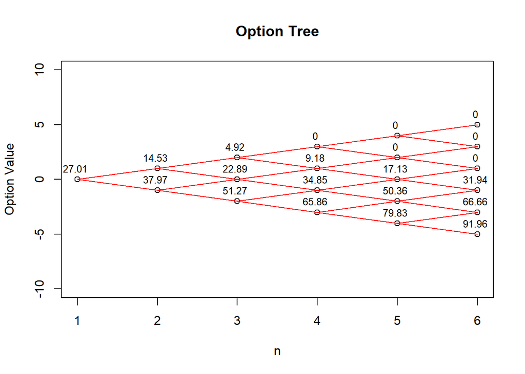

```r
CRRTree = BinomialTreeOption(TypeFlag = "pe", S = 150, X = 160, Time = 0.5, r =
0.06, b = 0, sigma = 0.5, n = 5)
BinomialTreePlot(CRRTree, dy = 1, cex = 0.8, ylim = c(-10, 10),xlab = "n", ylab
= "Option Value")
title(main = "Option Tree")
```

Black-Scholes Model

GBSOption(TypeFlag, S, X, Time, r, b, sigma, title = NULL, description = NULL)

Black-Scholes Call

```r
GBSOption(TypeFlag="c", S = 150, X = 160, Time = 0.5, r = 0.06, b = 0, sigma = 0.5)
```

```
##
## Title:
##  Black Scholes Option Valuation
##
## Call:
##  GBSOption(TypeFlag = "c", S = 150, X = 160, Time = 0.5, r = 0.06,
##      b = 0, sigma = 0.5)
##
## Parameters:
##           Value:
##  TypeFlag c
##  S        150
##  X        160
##  Time     0.5
##  r        0.06
##  b        0
##  sigma    0.5
##
## Option Price:
##  16.60088
##
## Description:
##  Thu Nov 19 23:48:56 2020
```

Black-Scholes Put

```r
GBSOption(TypeFlag="p", S = 150, X = 160, Time = 0.5, r = 0.06, b = 0, sigma = 0.5)
```

```
##
## Title:
##  Black Scholes Option Valuation
##
## Call:
##  GBSOption(TypeFlag = "p", S = 150, X = 160, Time = 0.5, r = 0.06,
##      b = 0, sigma = 0.5)
##
## Parameters:
##           Value:
##  TypeFlag p
##  S        150
##  X        160
##  Time     0.5
##  r        0.06
##  b        0
##  sigma    0.5
##
## Option Price:
##  26.30533
##
## Description:
##  Thu Nov 19 23:48:57 2020
```